# **Evaluating the Suitability of Lithic Illustrations in Morphometric Analyses**

Christian Steven Hoggard, Thomas Birch, Cory Marie Stade, Katrien Janin and Felix Riede

### **Abstract**

Illustrations of lithic artefacts are an abundant source of morphological and technological information for those interested in our human past. As a typical part of archaeological reports and publications, lithic drawings are - or have to be - trusted as faithful reproductions of the selected artefacts. Despite the considerable epistemic work lithic illustrations (and illustrators) are expected to do, usually little information is available regarding the illustrator’s technical skill; thus, it remains unknown whether drawings produced by illustrators of differing technical skill are comparable or produce images of equal analytical potential to other media, e.g. photographs. The issue of lithic illustration accuracy is brought to the fore by the recent emergence of geometric morphometric approaches as innovative and powerful ways of describing and analysing complex shapes, as lithic illustrations provide one of the key sources for such analyses. Motivated by these issues, we present an experiment investigating the degree of error observed in illustrations of differing technical illustrative skill. Analyses suggest that lithic illustrations produced by individuals with a variety of experience in drawing lithics create, in the majority of instances, equally faithful representations (in outline shape) of chipped stone artefacts. With error observed in a small number of instances, archaeologists are still urged to be critical of an illustration’s source prior to lineal and geometric morphometric methodologies. Despite this, archaeologists can be confident in their exactitude and we remain strong advocates in favour of lithic illustrations as a readily available legacy resource for morphometric analyses.

### **Introduction**

This is a R Markdown documented associated with the article *Evaluating the Suitability of Lithic Illustrations in Morphometric Analyses*, original research for *The Journal of the Lithic Studies Society* (http://www.lithics.org/). This Markdown document details the analytical procedure used throughout the article, from data importing and the packages used, to the univariate and multivariate framework underpinning the article’s findings.

### **Data files**

For this markdown, a number of different files are necessary:  
1. The three raw landmark files (for handaxe, tanged point and elongated artefacts), these are: **elongated.tps**, **handaxe.tps** and **tanged.tps**  
2. The three data frames for the respective landmark files: **elongated.csv**, **handaxe.csv** and **tanged.csv**  
3. The raw measurement length and width data for all artefacts: **measurement_data.csv**  
4) The files necessary to investigate landmark digitisation error: **digitisation_error.tps** and **digitisation_error.csv**  
5) The file necessary to investigate measurement error: **measurement_error.csv**  
6) The table of links for all landmark configurations: **curveslide.csv**

A copy of all files can also be found on GitHub and the Open Science Framework (OSF).  
GitHub: https://github.com/CSHoggard/-Lithic_Illustrations  
OSF: https://osf.io/xtghn/

### **Stage 1: Package installation and data extraction**

For this article, ten packages are required:  
1. **psych v.1.8.12** https://cran.r-project.org/web/packages/psych/index.html  
2. **geomorph v.3.1.2** https://cran.r-project.org/web/packages/geomorph/index.html  
3. **tidyverse v.1.2.1** https://cran.r-project.org/web/packages/tidyverse/index.html  
4. **vegan v.2.5-4** https://cran.r-project.org/web/packages/vegan/index.html  
5. **MASS v.7.3-51.4** https://cran.r-project.org/web/packages/MASS/index.html  
6. **cowplot v.0.9.3** https://cran.r-project.org/web/packages/cowplot/index.html  
7. **ggpubr v.0.9.3** https://cran.r-project.org/web/packages/ggpubr/index.html  
8. **rio v.0.5.16** https://cran.r-project.org/web/packages/rio/index.html  
9. **LaMBDA v.0.1.0.9000** https://rdrr.io/github/akiopteryx/lambda/  
10. **devtools v.2.3.1** https://cran.r-project.org/web/packages/devtools/index.html

The latest versions of each package can be installed and sourced through the following code:

```r
if(!require("psych")) install.packages('psych', repos='http://cran.us.r-project.org')
if(!require("geomorph")) install.packages('geomorph', repos='http://cran.us.r-project.org')
if(!require("tidyverse")) install.packages('tidyverse', repos='http://cran.us.r-project.org')
if(!require("vegan")) install.packages('vegan', repos='http://cran.us.r-project.org')
if(!require("MASS")) install.packages('MASS', repos='http://cran.us.r-project.org')
if(!require("cowplot")) install.packages('cowplot', repos='http://cran.us.r-project.org')
if(!require("ggpubr")) install.packages('ggpubr', repos='http://cran.us.r-project.org')
if(!require("rio")) install.packages('rio', repos='http://cran.us.r-project.org')
```

The `LaMBDA` package (LandMark-Based Data Assessment) is not on CRAN and requires downloading from GitHub (via the `devtools` package):

```r
install.packages(“devtools”)
devtools::install_github(“akiopteryx/lambda”)
```

Should specific functions become outdated then please refer to the package versions as cited above. Once downloaded, activate all packages:

```r
library(psych) ### load the listed package
library(geomorph) ### load the listed package
library(tidyverse) ### load the listed package
library(vegan) ### load the listed package
library(MASS) ### load the listed package
library(cowplot) ### load the listed package
library(ggpubr) ### load the listed package
library(LaMBDA) ### load the listed package
library(rio) ### load the listed package
```

### **Stage 1: Bringing all files into the R Environment**

Given the large number of files required for the individual analyses (shape analysis, metric analysis, digitisation error and measurement error), and to prevent issues of working directories, all files are brought into the R Environment as .rds objects; these are objects which were imported into R and stored on GitHub (and downloaded when required). Using the `rio::import()` function allows all objects to be brought into the workspace.

```r
landmarks_elongated <- import("https://github.com/CSHoggard/-Lithic_Illustrations/raw/master/landmarks_elongated.rds")
landmarks_handaxe <- import("https://github.com/CSHoggard/-Lithic_Illustrations/raw/master/landmarks_handaxe.rds")
landmarks_tanged <- import("https://github.com/CSHoggard/-Lithic_Illustrations/raw/master/landmarks_tanged.rds")
shape_data_elongated <- import("https://github.com/CSHoggard/-Lithic_Illustrations/raw/master/shape_data_elongated.rds")
shape_data_tanged <- import("https://github.com/CSHoggard/-Lithic_Illustrations/raw/master/shape_data_tanged.rds")
shape_data_handaxe <- import("https://github.com/CSHoggard/-Lithic_Illustrations/raw/master/shape_data_handaxe.rds")
metric_data <- import("https://github.com/CSHoggard/-Lithic_Illustrations/raw/master/metric_data.rds")
digitisation_error_landmarks <- import("https://github.com/CSHoggard/-Lithic_Illustrations/raw/master/digitisation_error_landmarks.rds")
digitisation_error_landmarks_data <- import("https://github.com/CSHoggard/-Lithic_Illustrations/raw/master/digitisation_error_landmarks_data.rds")
digitisation_error_metrics <- import("https://github.com/CSHoggard/-Lithic_Illustrations/raw/master/digitisation_error_metrics.rds")
shape_data_sliders <- import("https://github.com/CSHoggard/-Lithic_Illustrations/raw/master/shape_data_sliders.rds")
```

### **Stage 2: Sources of Error and Investigating Landmark Count**

### **Stage 2A: Digitisation and Landmark Error**

A Procrustes ANOVA (see in-text reference) was performed to calculate error associated with the digitisation of landmarks.

```r
gpa_digi_error <- gpagen(digitisation_error_landmarks, Proj = TRUE, curves =  shape_data_sliders, ProcD = TRUE, surfaces = NULL, print.progress = FALSE) ### formulates a generalised Procrustes analysis (GPA) file for repeated specimens
gpa_digi_error  ### calls the GPA landmark configuration
```

```
##
## Call:
## gpagen(A = digitisation_error_landmarks, curves = shape_data_sliders,
##     surfaces = NULL, ProcD = TRUE, Proj = TRUE, print.progress = FALSE)
##
##
##
## Generalized Procrustes Analysis
## with Partial Procrustes Superimposition
##
## 2 fixed landmarks
## 18 semilandmarks (sliders)
## 2-dimensional landmarks
## 3 GPA iterations to converge
## Minimized squared Procrustes Distance used
##
##
## Consensus (mean) Configuration
##
##              X            Y
## 1  -0.31796682 -0.132644965
## 2  -0.31060449 -0.088929377
## 3  -0.28269701 -0.053436920
## 4  -0.25585407 -0.018405380
## 5  -0.22179239  0.010680904
## 6  -0.17917516  0.024001159
## 7  -0.13525110  0.034933759
## 8  -0.09809871  0.058525436
## 9  -0.05547201  0.073540152
## 10 -0.01513393  0.092829862
## 11  0.02965721  0.095950162
## 12  0.07472658  0.091629691
## 13  0.11822149  0.083726851
## 14  0.15801543  0.063045388
## 15  0.19363531  0.037275511
## 16  0.22441752  0.004551561
## 17  0.24271449 -0.034206469
## 18  0.25597780 -0.075621222
## 19  0.28077551 -0.112520244
## 20  0.29390492 -0.154928393
```

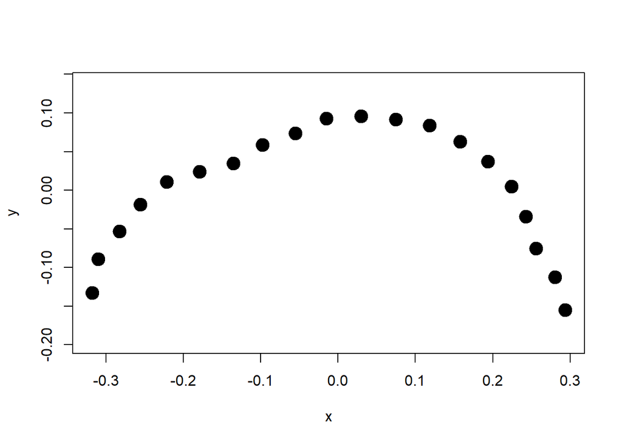

```r
plot(gpa_digi_error) ### visualisation of the landmark configuration
```

```r
gpa_digi_error_df <- geomorph.data.frame(gpa_digi_error, attempt = digitisation_error_landmarks_data$Attempt)
gpaprocD <- procD.lm(coords ~ attempt, data = gpa_digi_error_df, print.progress = FALSE) ### ANOVA (coordinates vs. attempt)
summary(gpaprocD) ### summary
```

```
##
## Analysis of Variance, using Residual Randomization
## Permutation procedure: Randomization of null model residuals
## Number of permutations: 1000
## Estimation method: Ordinary Least Squares
## Sums of Squares and Cross-products: Type I
## Effect sizes (Z) based on F distributions
##
##           Df         SS         MS   Rsq      F       Z Pr(>F)
## attempt    1 1.1246e-06 1.1246e-06 0.086 0.2823 -2.2192 0.9915
## Residuals  3 1.1952e-05 3.9841e-06 0.914
## Total      4 1.3077e-05
##
## Call: procD.lm(f1 = coords ~ attempt, data = gpa_digi_error_df, print.progress = FALSE)
```

```r
gpaprocD$aov.table$SS[1]/gpaprocD$aov.table$SS[3]*100 ### error expressed as a percentage (8.599812%)
```

```
## [1] 8.599812
```

### **Stage 2B: Measurement Error**

To calculate error associated with lineal measurements fractional uncertainity (standard error divided by the mean) was calculated:

```r
head(digitisation_error_metrics)
```

```
##                  Attempt Scale_Factor Length_mm Width_mm
## T_Image_1_Copy_1       1     0.026200     82.15    22.51
## T_Image_1_Copy_2       2     0.026390     82.77    22.61
## T_Image_1_Copy_3       3     0.026080     81.80    22.29
## T_Image_1_Copy_4       4     0.026140     82.01    22.30
## T_Image_1_Copy_5       5     0.026110     81.98    22.35
## T_Image_1_Copy_6       6     0.026316     82.55    22.26
```

```r
statsl  <- describe(digitisation_error_metrics$Length_mm) ### descriptive statistics
statsw  <- describe(digitisation_error_metrics$Width_mm) ### descriptive statistics
statssf <- describe(digitisation_error_metrics$Scale_Factor) ### descriptive statistics

(statsl$se/statsl$mean)   * 100 ### fractional uncertainity (length)
```

```
## [1] 0.1188221
```

```r
(statsw$se/statsw$mean)   * 100 ### fractional uncertainity (width)
```

```
## [1] 0.2275143
```

```r
(statssf$se/statssf$mean) * 100 ### fractional uncertainity (scale factor: as calibrated through tpsDig2)
```

```
## [1] 0.1223673
```

### **Stage 2C: Investigating Landmark Number**

The `LaMBDA::LaSEC()` function is used to assess the fidelity of morphological characterisation. This function helps the user to identify under- and over-sampling of landmarks, the robustness of the characterisation and determine how many landmarks can be removed without compromising the necessary shape information. A two-dimensional array of each landmark file was used, with 500 iterations, to determine if twenty landmarks were suitable. 500 iterations were used for the analysis, here 10 iterations are exemplified (for ease and speed):

```r
lasec(two.d.array(landmarks_elongated), 2, iter = 10, show.progress = F) ### may take some time
```

```
## $fit
##       [,1] [,2]      [,3]      [,4]      [,5]      [,6]      [,7]      [,8]
##  [1,]   NA   NA 0.4266091 0.6147560 0.6751330 0.7340831 0.7404959 0.7259068
##  [2,]   NA   NA 0.3369609 0.4047617 0.6690733 0.7630186 0.7717525 0.7863335
##  [3,]   NA   NA 0.2117912 0.6014738 0.6885139 0.7801914 0.8324604 0.8501878
##  [4,]   NA   NA 0.3833677 0.6448295 0.7296465 0.8013079 0.8271597 0.8391232
##  [5,]   NA   NA 0.4858948 0.5475603 0.5746519 0.5939085 0.6099498 0.7263266
##  [6,]   NA   NA 0.1496894 0.1828957 0.2282708 0.4198239 0.5595475 0.6316915
##  [7,]   NA   NA 0.2492960 0.3903325 0.6014808 0.6176988 0.6858696 0.7231616
##  [8,]   NA   NA 0.2185810 0.3534511 0.4355959 0.5330820 0.5803528 0.6000358
##  [9,]   NA   NA 0.1045264 0.2621953 0.3289382 0.4348423 0.7035339 0.7909908
## [10,]   NA   NA 0.3921624 0.4822764 0.5075159 0.5811851 0.6324589 0.6614188
##            [,9]     [,10]     [,11]     [,12]     [,13]     [,14]     [,15]
##  [1,] 0.7317716 0.7607066 0.7727718 0.9353395 0.9403264 0.9624219 0.9696455
##  [2,] 0.7994903 0.8742647 0.8918639 0.9108705 0.9295962 0.9356827 0.9477314
```

[output cut: 35 more lines]

```r
lasec(two.d.array(landmarks_tanged), 2, iter = 10, show.progress = F) ### may take some time
```

```
## $fit
##       [,1] [,2]      [,3]      [,4]      [,5]      [,6]      [,7]      [,8]
##  [1,]   NA   NA 0.4217917 0.6047505 0.6392495 0.6640790 0.7159194 0.9289021
##  [2,]   NA   NA 0.4009467 0.6092243 0.7652525 0.7712699 0.7858774 0.9386633
##  [3,]   NA   NA 0.3437907 0.5432440 0.5253483 0.5103545 0.8293903 0.8475342
##  [4,]   NA   NA 0.3980624 0.4278432 0.6579940 0.7089972 0.7098521 0.9287454
##  [5,]   NA   NA 0.2482981 0.3286939 0.4043061 0.6816333 0.8229819 0.8222356
##  [6,]   NA   NA 0.4435165 0.5821779 0.8710323 0.8815043 0.8984517 0.9065570
##  [7,]   NA   NA 0.4365306 0.6067338 0.8561123 0.8856661 0.8932322 0.8963199
##  [8,]   NA   NA 0.1380896 0.5977218 0.7125548 0.7185235 0.7478528 0.8394642
##  [9,]   NA   NA 0.2210797 0.4933054 0.6225637 0.6482471 0.6453302 0.8406943
## [10,]   NA   NA 0.5410143 0.6534842 0.6720500 0.7671213 0.7716416 0.8943620
##            [,9]     [,10]     [,11]     [,12]     [,13]     [,14]     [,15]
##  [1,] 0.9361425 0.9288203 0.9387569 0.9393310 0.9739875 0.9752750 0.9819006
##  [2,] 0.9417356 0.9543753 0.9567695 0.9576946 0.9714646 0.9838562 0.9859071
```

[output cut: 35 more lines]

```r
lasec(two.d.array(landmarks_handaxe), 2, iter = 10, show.progress = F) ### may take some time
```

```
## $fit
##       [,1] [,2]       [,3]       [,4]      [,5]      [,6]      [,7]      [,8]
##  [1,]   NA   NA 0.81841906 0.83667919 0.9278043 0.9381068 0.9515107 0.9643212
##  [2,]   NA   NA 0.26515479 0.80618335 0.8569551 0.8767420 0.8996060 0.9091646
##  [3,]   NA   NA 0.84753024 0.91247198 0.9283975 0.9298322 0.9417550 0.9485294
##  [4,]   NA   NA 0.61746456 0.79730558 0.9498652 0.9605661 0.9680502 0.9695866
##  [5,]   NA   NA 0.70929339 0.75103593 0.9208991 0.9262072 0.9419255 0.9516471
##  [6,]   NA   NA 0.01013168 0.08422457 0.2922126 0.4004322 0.9334258 0.9499524
##  [7,]   NA   NA 0.08705009 0.79987489 0.8223479 0.9172556 0.9475008 0.9546063
##  [8,]   NA   NA 0.84500151 0.84468770 0.9160721 0.9221039 0.9149956 0.9371465
##  [9,]   NA   NA 0.21264361 0.50291388 0.5398543 0.6088447 0.9345187 0.9443875
## [10,]   NA   NA 0.43876402 0.72874988 0.6884355 0.8910890 0.8833116 0.8985999
##            [,9]     [,10]     [,11]     [,12]     [,13]     [,14]     [,15]
##  [1,] 0.9728473 0.9758360 0.9805483 0.9854658 0.9869850 0.9891454 0.9906895
##  [2,] 0.9461942 0.9534428 0.9629319 0.9656618 0.9689024 0.9709830 0.9876714
```

[output cut: 35 more lines]

### **Stage 3: Generalised Procrustes Analysis (GPA)**

With all errors calculated and deemed insignificant, we can now transform each artefact class through a GPA using the `geomorph::gpagen()` function as above:

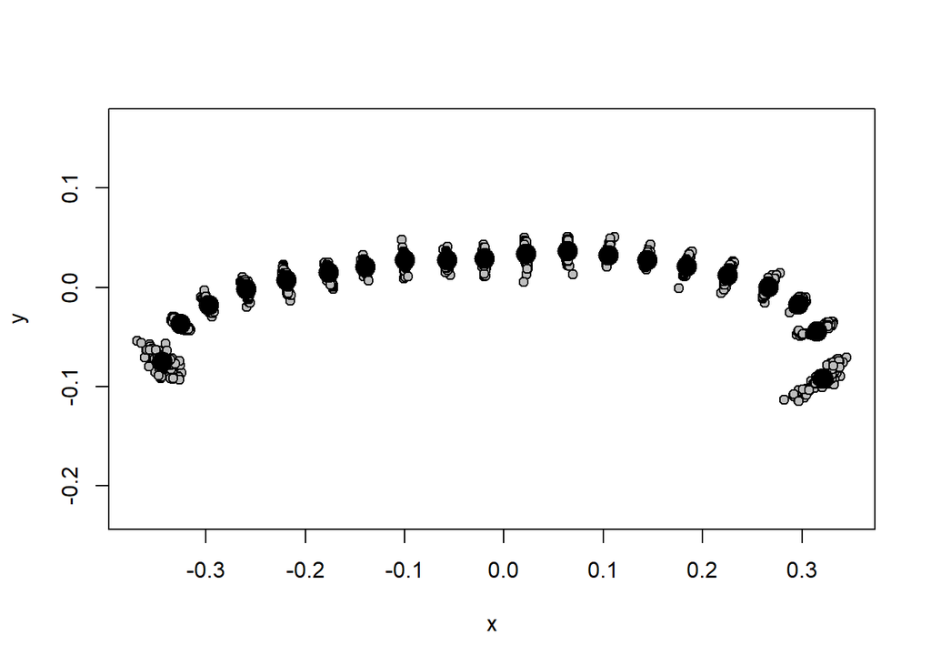

```r
gpa_elongated <- gpagen(landmarks_elongated, Proj = TRUE, ProcD = TRUE, curves = shape_data_sliders, surfaces = NULL, print.progress = FALSE) ### gpa (using a procrustes distance criterion): all elongated artefacts
plot(gpa_elongated) ### plots the procrustes coordinates for all elongated artefacts
```

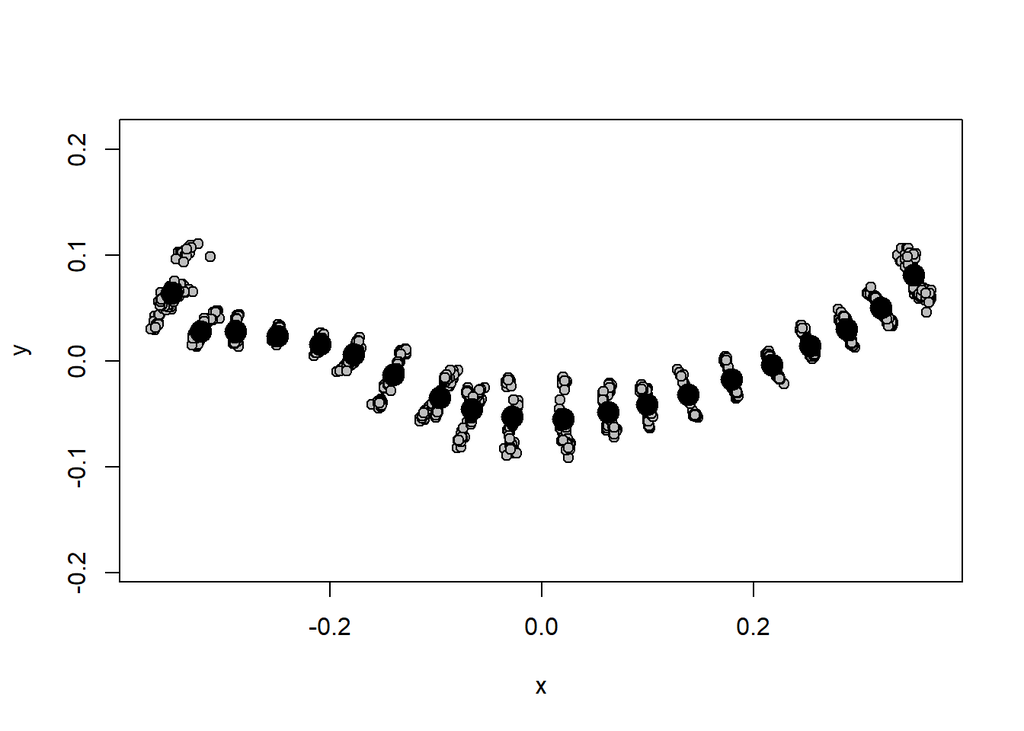

```r
gpa_tanged <- gpagen(landmarks_tanged, Proj = TRUE, ProcD = TRUE, curves = shape_data_sliders, surfaces = NULL, print.progress = FALSE) ### gpa (procrustes distance criterion): all tanged artefacts
plot(gpa_tanged) ### plots the procrustes coordinates for all tanged artefacts
```

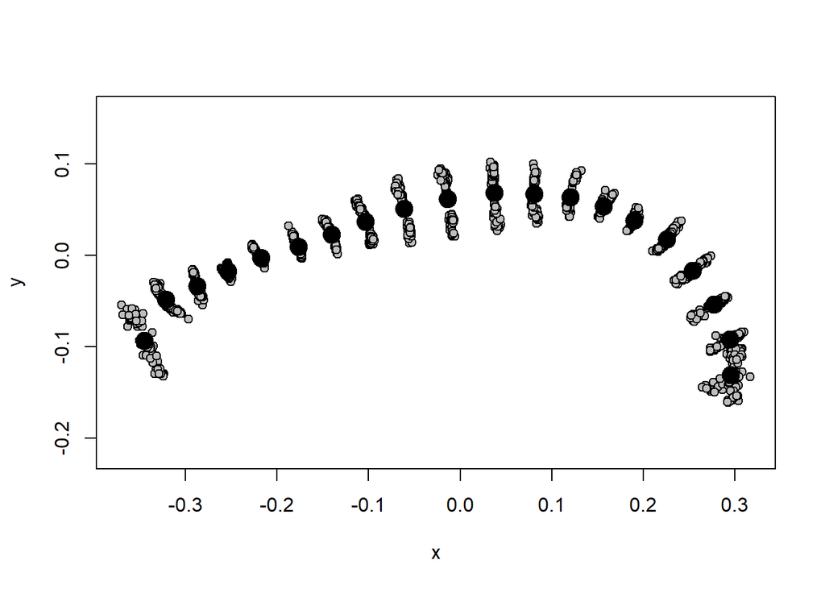

```r
gpa_handaxe <- gpagen(landmarks_handaxe, Proj = TRUE, ProcD = TRUE, curves = shape_data_sliders, surfaces = NULL, print.progress = FALSE) ### gpa (Procrustes distance criterion): all handaxe artefacts
plot(gpa_handaxe) ### plots the procrustes coordinates for all handaxe artefacts
```

### **Stage 4: Exploratory Analysis through Principal Component Analysis (PCA)**

Individual PCAs for all artefact classes were created to visualise differences in illustration skill between and within the different artefacts. PCAs were made in geomorph, through the `geomorph:gm.prcomp()` function, before being exported and modified (for better visualisation) in the tidyverse Note: specific shape differences can be calculated through the created files. The visualisations can then be exported through the `tidyverse:ggsave()` function.

```r
pca_elongated <- gm.prcomp(gpa_elongated$coords) ### pca (geomorph)
pca_elongated ### pca summary
```

```
##
## Ordination type: Principal Component Analysis
## Centering and projection: OLS
## Number of observations 90
## Number of vectors 40
##
## Importance of Components:
##                               Comp1        Comp2        Comp3        Comp4
## Eigenvalues            0.0006240892 0.0003309824 0.0001584863 5.961311e-05
## Proportion of Variance 0.4581554039 0.2429803127 0.1163477493 4.376308e-02
## Cumulative Proportion  0.4581554039 0.7011357166 0.8174834660 8.612466e-01
##                               Comp5        Comp6        Comp7        Comp8
## Eigenvalues            3.529451e-05 3.177163e-05 0.0000203628 1.880991e-05
## Proportion of Variance 2.591035e-02 2.332414e-02 0.0149487086 1.380870e-02
## Cumulative Proportion  8.871569e-01 9.104810e-01 0.9254297512 9.392385e-01
##                               Comp9       Comp10       Comp11       Comp12
## Eigenvalues            1.340489e-05 1.198961e-05 1.008453e-05 8.642198e-06
## Proportion of Variance 9.840777e-03 8.801791e-03 7.403236e-03 6.344397e-03
## Cumulative Proportion  9.490792e-01 9.578810e-01 9.652843e-01 9.716287e-01
##                              Comp13       Comp14       Comp15       Comp16
## Eigenvalues            6.693848e-06 5.406835e-06 4.978051e-06 4.684685e-06
## Proportion of Variance 4.914078e-03 3.969257e-03 3.654479e-03 3.439114e-03
## Cumulative Proportion  9.765427e-01 9.805120e-01 9.841665e-01 9.876056e-01
##                              Comp17       Comp18       Comp19       Comp20
## Eigenvalues            3.897801e-06 3.361388e-06 2.190264e-06 1.677687e-06
## Proportion of Variance 2.861448e-03 2.467657e-03 1.607913e-03 1.231621e-03
## Cumulative Proportion  9.904670e-01 9.929347e-01 9.945426e-01 9.957742e-01
##                              Comp21       Comp22       Comp23       Comp24
## Eigenvalues            1.463887e-06 8.279955e-07 7.209098e-07 5.838376e-07
## Proportion of Variance 1.074666e-03 6.078468e-04 5.292332e-04 4.286060e-04
## Cumulative Proportion  9.968489e-01 9.974567e-01 9.979860e-01 9.984146e-01
##                              Comp25       Comp26       Comp27       Comp28
## Eigenvalues            3.725275e-07 3.456928e-07 2.633273e-07 2.420822e-07
## Proportion of Variance 2.734793e-04 2.537795e-04 1.933134e-04 1.777170e-04
## Cumulative Proportion  9.986881e-01 9.989418e-01 9.991351e-01 9.993129e-01
##                              Comp29       Comp30       Comp31       Comp32
## Eigenvalues            2.363967e-07 1.846166e-07 1.492681e-07 1.177400e-07
## Proportion of Variance 1.735432e-04 1.355305e-04 1.095805e-04 8.643509e-05
## Cumulative Proportion  9.994864e-01 9.996219e-01 9.997315e-01 9.998180e-01
##                              Comp33       Comp34       Comp35       Comp36
## Eigenvalues            8.787721e-08 7.107291e-08 4.752191e-08 2.573367e-08
## Proportion of Variance 6.451228e-05 5.217594e-05 3.488671e-05 1.889157e-05
## Cumulative Proportion  9.998825e-01 9.999346e-01 9.999695e-01 9.999884e-01
##                              Comp37       Comp38       Comp39       Comp40
## Eigenvalues            1.454692e-08 1.228972e-09 1.832541e-22 5.967109e-34
## Proportion of Variance 1.067916e-05 9.022114e-07 1.345302e-19 4.380565e-31
## Cumulative Proportion  9.999991e-01 1.000000e+00 1.000000e+00 1.000000e+00
```

```r
elongated_ds <- cbind(shape_data_elongated, pca_elongated$x) ### tidyverse compatible format

pca_tanged <- gm.prcomp(gpa_tanged$coords) ### pca (geomorph)
pca_tanged ### pca summary
```

```
##
## Ordination type: Principal Component Analysis
## Centering and projection: OLS
## Number of observations 90
## Number of vectors 40
##
## Importance of Components:
##                              Comp1       Comp2        Comp3       Comp4
## Eigenvalues            0.002108332 0.001407887 0.0002833669 0.000161115
## Proportion of Variance 0.508049684 0.339261820 0.0682835983 0.038824262
## Cumulative Proportion  0.508049684 0.847311504 0.9155951019 0.954419364
##                               Comp5        Comp6        Comp7        Comp8
## Eigenvalues            4.604155e-05 2.857256e-05 1.833576e-05 1.477163e-05
## Proportion of Variance 1.109474e-02 6.885197e-03 4.418412e-03 3.559556e-03
## Cumulative Proportion  9.655141e-01 9.723993e-01 9.768177e-01 9.803773e-01
##                               Comp9       Comp10       Comp11       Comp12
## Eigenvalues            1.262627e-05 9.103601e-06 8.270341e-06 7.226064e-06
## Proportion of Variance 3.042582e-03 2.193716e-03 1.992924e-03 1.741282e-03
## Cumulative Proportion  9.834199e-01 9.856136e-01 9.876065e-01 9.893478e-01
##                              Comp13       Comp14       Comp15       Comp16
## Eigenvalues            6.433424e-06 0.0000059361 4.986095e-06 4.260570e-06
## Proportion of Variance 1.550278e-03 0.0014304362 1.201511e-03 1.026680e-03
## Cumulative Proportion  9.908981e-01 0.9923284887 9.935300e-01 9.945567e-01
##                              Comp17       Comp18       Comp19       Comp20
## Eigenvalues            3.425980e-06 2.990619e-06 2.843070e-06 2.461052e-06
## Proportion of Variance 8.255666e-04 7.206566e-04 6.851013e-04 5.930455e-04
## Cumulative Proportion  9.953822e-01 9.961029e-01 9.967880e-01 9.973810e-01
##                              Comp21       Comp22       Comp23       Comp24
## Eigenvalues            2.244288e-06 1.821357e-06 1.559110e-06 1.216749e-06
## Proportion of Variance 5.408114e-04 4.388967e-04 3.757024e-04 2.932029e-04
## Cumulative Proportion  9.979219e-01 9.983608e-01 9.987365e-01 9.990297e-01
##                              Comp25       Comp26       Comp27       Comp28
## Eigenvalues            7.597572e-07 5.893029e-07 5.709725e-07 4.840509e-07
## Proportion of Variance 1.830805e-04 1.420057e-04 1.375886e-04 1.166429e-04
## Cumulative Proportion  9.992127e-01 9.993547e-01 9.994923e-01 9.996090e-01
##                              Comp29       Comp30       Comp31       Comp32
## Eigenvalues            4.310409e-07 2.515842e-07 2.356631e-07 2.089888e-07
## Proportion of Variance 1.038689e-04 6.062485e-05 5.678829e-05 5.036052e-05
## Cumulative Proportion  9.997128e-01 9.997735e-01 9.998303e-01 9.998806e-01
##                              Comp33       Comp34       Comp35       Comp36
## Eigenvalues            1.713893e-07 1.193250e-07 1.144246e-07 5.925712e-08
## Proportion of Variance 4.130009e-05 2.875404e-05 2.757317e-05 1.427933e-05
## Cumulative Proportion  9.999219e-01 9.999507e-01 9.999783e-01 9.999925e-01
##                              Comp37       Comp38       Comp39      Comp40
## Eigenvalues            2.710922e-08 3.891138e-09 8.741952e-23 1.53472e-33
## Proportion of Variance 6.532573e-06 9.376569e-07 2.106569e-20 3.69825e-31
## Cumulative Proportion  9.999991e-01 1.000000e+00 1.000000e+00 1.00000e+00
```

```r
tanged_ds <- cbind(shape_data_tanged, pca_tanged$x) ### tidyverse compatible format

pca_handaxe <- gm.prcomp(gpa_handaxe$coords) ### pca (geomorph)
pca_handaxe ### pca summary
```

```
##
## Ordination type: Principal Component Analysis
## Centering and projection: OLS
## Number of observations 90
## Number of vectors 40
##
## Importance of Components:
##                              Comp1        Comp2        Comp3        Comp4
## Eigenvalues            0.004147443 0.0003415703 0.0001480715 5.776983e-05
## Proportion of Variance 0.848362755 0.0698684628 0.0302881402 1.181686e-02
## Cumulative Proportion  0.848362755 0.9182312181 0.9485193583 9.603362e-01
##                               Comp5        Comp6        Comp7        Comp8
## Eigenvalues            3.702773e-05 2.686763e-05 1.884701e-05 1.644421e-05
## Proportion of Variance 7.574051e-03 5.495794e-03 3.855170e-03 3.363675e-03
## Cumulative Proportion  9.679103e-01 9.734061e-01 9.772612e-01 9.806249e-01
##                               Comp9       Comp10       Comp11       Comp12
## Eigenvalues            1.401099e-05 1.294287e-05 1.019683e-05 8.733280e-06
## Proportion of Variance 2.865959e-03 2.647474e-03 2.085770e-03 1.786399e-03
## Cumulative Proportion  9.834909e-01 9.861383e-01 9.882241e-01 9.900105e-01
##                              Comp13       Comp14       Comp15       Comp16
## Eigenvalues            7.370640e-06 6.467041e-06 4.826731e-06 4.408248e-06
## Proportion of Variance 1.507670e-03 1.322838e-03 9.873115e-04 9.017105e-04
## Cumulative Proportion  9.915182e-01 9.928410e-01 9.938283e-01 9.947300e-01
##                              Comp17       Comp18       Comp19       Comp20
## Eigenvalues            3.801114e-06 3.306690e-06 3.009149e-06 2.486183e-06
## Proportion of Variance 7.775208e-04 6.763861e-04 6.155238e-04 5.085508e-04
## Cumulative Proportion  9.955076e-01 9.961840e-01 9.967995e-01 9.973080e-01
##                              Comp21       Comp22       Comp23       Comp24
## Eigenvalues            2.276660e-06 1.958038e-06 1.744844e-06 1.488234e-06
## Proportion of Variance 4.656925e-04 4.005181e-04 3.569091e-04 3.044195e-04
## Cumulative Proportion  9.977737e-01 9.981742e-01 9.985311e-01 9.988356e-01
##                              Comp25       Comp26       Comp27       Comp28
## Eigenvalues            1.367614e-06 8.485558e-07 8.095846e-07 7.015244e-07
## Proportion of Variance 2.797465e-04 1.735727e-04 1.656012e-04 1.434974e-04
## Cumulative Proportion  9.991153e-01 9.992889e-01 9.994545e-01 9.995980e-01
##                              Comp29       Comp30       Comp31       Comp32
## Eigenvalues            5.635145e-07 3.907648e-07 2.811766e-07 2.106388e-07
## Proportion of Variance 1.152673e-04 7.993123e-05 5.751488e-05 4.308632e-05
## Cumulative Proportion  9.997133e-01 9.997932e-01 9.998507e-01 9.998938e-01
##                              Comp33       Comp34       Comp35       Comp36
## Eigenvalues            1.589855e-07 1.475755e-07 1.146792e-07 7.430645e-08
## Proportion of Variance 3.252060e-05 3.018668e-05 2.345772e-05 1.519944e-05
## Cumulative Proportion  9.999263e-01 9.999565e-01 9.999799e-01 9.999951e-01
##                              Comp37       Comp38       Comp39       Comp40
## Eigenvalues            1.945077e-08 4.274790e-09 2.907959e-21 9.892121e-34
## Proportion of Variance 3.978670e-06 8.744115e-07 5.948252e-19 2.023441e-31
## Cumulative Proportion  9.999991e-01 1.000000e+00 1.000000e+00 1.000000e+00
```